# Greg Walsh PCA

```r
save.image("PCAimage.Rmd")
```

```r
library(tidyverse)
library("FactoMineR")
library("factoextra")
```

```r
setwd("C:/Users/Gregwalsh96/github/DataScience/DSSA-5201-MACHINE-LEARNING-FUNDAMENTALS/PCA")
data <- read.csv("data.csv", header = TRUE)
getwd()
```

```
[1] "C:/Users/Gregwalsh96/github/DataScience/DSSA-5201-MACHINE-LEARNING-FUNDAMENTALS/PCA"
```

```r
# Interested in what team has the most players
count(data, c("Nationality")) %>% arrange(desc(freq))
```

| Nationality | freq |
| --- | --- |
| England | 1662 |
| Germany | 1198 |
| Spain | 1072 |
| Argentina | 937 |
| France | 914 |
| Brazil | 827 |
| Italy | 702 |
| Colombia | 618 |
| Japan | 478 |
| Netherlands | 453 |

[output cut: 154 more lines]

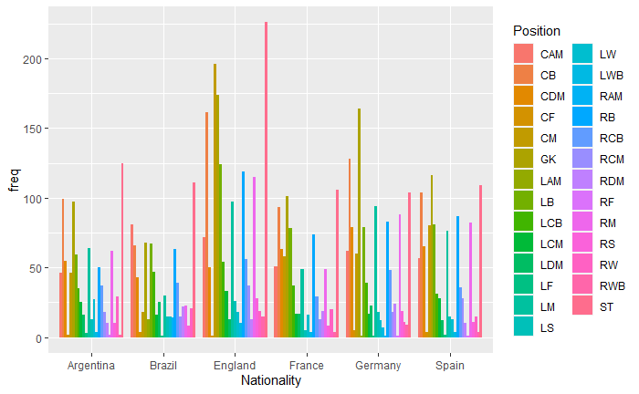

```r
# saw an interesting graph on Kaggle of someone looking at the data of
# Nationality by Position in Python so I recreated it in R
England <- filter(data, Nationality %in% c("England")) %>% select(Nationality, Position) %>% count("Position") %>% mutate(Nationality="England")
Germany <- filter(data, Nationality %in% c("Germany")) %>% select(Nationality, Position) %>% count %>% mutate(Nationality="Germany")
Spain <- filter(data, Nationality %in% c("Spain")) %>% select(Nationality, Position) %>% count("Position") %>% mutate(Nationality="Spain")
France <- filter(data, Nationality %in% c("France")) %>% select(Nationality, Position) %>% count("Position") %>% mutate(Nationality="France")
Argentina <- filter(data, Nationality %in% c("Argentina")) %>% select(Nationality, Position) %>% count("Position") %>% mutate(Nationality="Argentina")
Brazil <- filter(data, Nationality %in% c("Brazil")) %>% select(Nationality, Position) %>% count("Position") %>% mutate(Nationality="Brazil")
df <- rbind(England, Germany, Spain, France, Argentina, Brazil)
natplt <- ggplot(df, aes(Nationality, freq))
natplt + geom_bar(stat = "identity", aes(fill = Position), position = "dodge")
```

```r
# Check for NA's
any(is.na(data))
```

```
[1] TRUE
```

```r
# Remove NA's this is typically bad and should not be done
# Removing NA Values should be replaced with the mean to help with variance
# However it was easier to just remove them since the focus of this is on PCA
data<-na.omit(data)
# NA values removed
any(is.na(data))
```

```
[1] FALSE
```

```r
dim(data)
```

```
[1] 18147    89
```

```r
# 18147 observations
# 89 variables
```

```r
datapca <- data[55:83]

# head the data
head(datapca)
```

|  | Crossing | Finishing | HeadingAccuracy | ShortPassing | Volleys | Dribbling | Curve | FKAccuracy | LongPassing | BallControl | Acceleration | SprintSpeed | Agility | Reactions | Balance | ShotPower | Jumping | Stamina | Strength | LongShots | Aggression | Interceptions | Positioning | Vision | Penalties | Composure | Marking | StandingTackle | SlidingTackle |
| --- | --- | --- | --- | --- | --- | --- | --- | --- | --- | --- | --- | --- | --- | --- | --- | --- | --- | --- | --- | --- | --- | --- | --- | --- | --- | --- | --- | --- | --- |
| 1 | 84 | 95 | 70 | 90 | 86 | 97 | 93 | 94 | 87 | 96 | 91 | 86 | 91 | 95 | 95 | 85 | 68 | 72 | 59 | 94 | 48 | 22 | 94 | 94 | 75 | 96 | 33 | 28 | 26 |
| 2 | 84 | 94 | 89 | 81 | 87 | 88 | 81 | 76 | 77 | 94 | 89 | 91 | 87 | 96 | 70 | 95 | 95 | 88 | 79 | 93 | 63 | 29 | 95 | 82 | 85 | 95 | 28 | 31 | 23 |
| 3 | 79 | 87 | 62 | 84 | 84 | 96 | 88 | 87 | 78 | 95 | 94 | 90 | 96 | 94 | 84 | 80 | 61 | 81 | 49 | 82 | 56 | 36 | 89 | 87 | 81 | 94 | 27 | 24 | 33 |
| 4 | 17 | 13 | 21 | 50 | 13 | 18 | 21 | 19 | 51 | 42 | 57 | 58 | 60 | 90 | 43 | 31 | 67 | 43 | 64 | 12 | 38 | 30 | 12 | 68 | 40 | 68 | 15 | 21 | 13 |
| 5 | 93 | 82 | 55 | 92 | 82 | 86 | 85 | 83 | 91 | 91 | 78 | 76 | 79 | 91 | 77 | 91 | 63 | 90 | 75 | 91 | 76 | 61 | 87 | 94 | 79 | 88 | 68 | 58 | 51 |
| 6 | 81 | 84 | 61 | 89 | 80 | 95 | 83 | 79 | 83 | 94 | 94 | 88 | 95 | 90 | 94 | 82 | 56 | 83 | 66 | 80 | 54 | 41 | 87 | 89 | 86 | 91 | 34 | 27 | 22 |

```r
# set seed
set.seed(123)

# Column names
# colnames(datapca)

# Apply pca using prcomp
fifaprcomp <- prcomp(datapca, center = TRUE, scale. = TRUE)
summary(fifaprcomp)
```

```
Importance of components:
                          PC1    PC2     PC3     PC4     PC5     PC6     PC7     PC8     PC9    PC10    PC11    PC12
Standard deviation     3.9439 2.1836 1.39835 1.16779 1.00370 0.78733 0.62602 0.59372 0.54798 0.52450 0.49222 0.47404
Proportion of Variance 0.5363 0.1644 0.06743 0.04703 0.03474 0.02138 0.01351 0.01216 0.01035 0.00949 0.00835 0.00775
Cumulative Proportion  0.5363 0.7008 0.76819 0.81522 0.84996 0.87133 0.88485 0.89700 0.90736 0.91684 0.92520 0.93295
                          PC13    PC14   PC15   PC16   PC17   PC18    PC19    PC20    PC21    PC22    PC23    PC24
Standard deviation     0.47106 0.44940 0.4474 0.4171 0.3847 0.3690 0.35484 0.34842 0.33056 0.30846 0.28871 0.26868
Proportion of Variance 0.00765 0.00696 0.0069 0.0060 0.0051 0.0047 0.00434 0.00419 0.00377 0.00328 0.00287 0.00249
Cumulative Proportion  0.94060 0.94756 0.9545 0.9605 0.9656 0.9703 0.97460 0.97879 0.98256 0.98584 0.98871 0.99120
                          PC25    PC26    PC27    PC28    PC29
Standard deviation     0.26126 0.25519 0.24777 0.19333 0.15166
Proportion of Variance 0.00235 0.00225 0.00212 0.00129 0.00079
Cumulative Proportion  0.99356 0.99580 0.99792 0.99921 1.00000
```

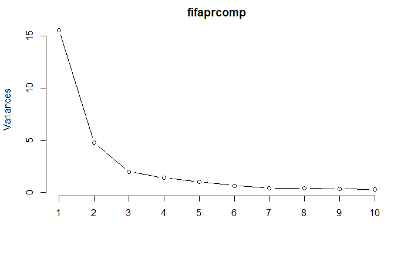

```r
screeplot(fifaprcomp, type = "lines")
```

From the scree plot we can see that 2-3 Components contain most the variance

First three components show 53.63% on the first 70.08% on the second and 76.81% on the third. This means we can narrow down our components from the original dataset to the first 2 principal components.

```r
fifaprcomp$rotation[,1:3]
```

```
                        PC1         PC2          PC3
Crossing        -0.22396739 -0.01613324 -0.117493061
Finishing       -0.20287481 -0.20644012  0.146399308
HeadingAccuracy -0.16820067  0.18255772  0.161231666
ShortPassing    -0.23320271  0.06164831  0.010502683
Volleys         -0.21037001 -0.15721963  0.163404744
Dribbling       -0.23633780 -0.08640666 -0.063211454
Curve           -0.22331114 -0.09233626  0.026316916
FKAccuracy      -0.20916979 -0.06951938  0.070471415
LongPassing     -0.20984597  0.10302473 -0.003395529
BallControl     -0.24231728 -0.01531958  0.001081830
Acceleration    -0.18022422 -0.12324333 -0.333242351
SprintSpeed     -0.17724688 -0.10207012 -0.300067786
Agility         -0.18890274 -0.14816074 -0.271716937
Reactions       -0.12899567  0.07242506  0.283014701
Balance         -0.16194784 -0.13322946 -0.373272361
ShotPower       -0.22057083 -0.05972983  0.175070628
Jumping         -0.06734998  0.13269202 -0.015681865
Stamina         -0.20022106  0.12118921 -0.103241028
Strength        -0.02935601  0.24966214  0.401554770
LongShots       -0.22283342 -0.12028764  0.139481510
Aggression      -0.15527141  0.28428560  0.063899390
Interceptions   -0.12080613  0.37257444 -0.106116544
Positioning     -0.22426456 -0.13425964  0.046653180
Vision          -0.19421826 -0.11181335  0.115357783
Penalties       -0.20208383 -0.13288617  0.165822181
Composure       -0.18406255  0.05561048  0.244400346
Marking         -0.12605182  0.35332345 -0.126318062
StandingTackle  -0.11801114  0.37658385 -0.146138090
SlidingTackle   -0.10967812  0.37792095 -0.174106195
```

Using the first two PCA’s we can look at what variables contribute the most to Principal Components. First we need to see what data contributes the most to the first Principal Component.

```r
contrib <- fifaprcomp$rotation[,1] / sum(fifaprcomp$rotation[,1])
head(contrib[order(-contrib)])
```

```
 BallControl    Dribbling ShortPassing  Positioning     Crossing        Curve
  0.04685453   0.04569833   0.04509213   0.04336385   0.04330639   0.04317950
```

Looks like BallControl is the data that contributes the most to the first Principal Component.

```r
contrib <- fifaprcomp$rotation[,2] / sum(fifaprcomp$rotation[,2])
head(contrib[order(-contrib)])
```

```
 SlidingTackle StandingTackle  Interceptions        Marking     Aggression       Strength
     0.3653377      0.3640451      0.3601692      0.3415592      0.2748200      0.2413494
```

For the second component Sliding Tackle contributes the most.

```r
contrib <- fifaprcomp$rotation[,3] / sum(fifaprcomp$rotation[,3])
head(contrib[order(-contrib)])
```

```
 Strength Reactions Composure ShotPower Penalties   Volleys
 4.978253  3.508659  3.029940  2.170428  2.055771  2.025801
```

and for the third it is strength however the contribution is way off at 4.97 compared to others that are 0.36 and 0.04. Not sure why we are over .99 if its a percentage.

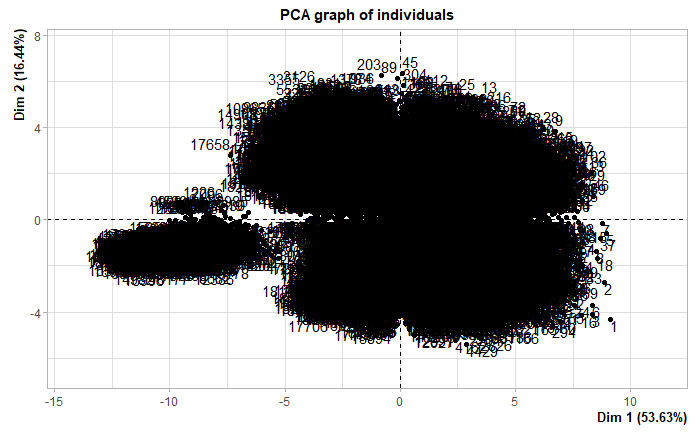

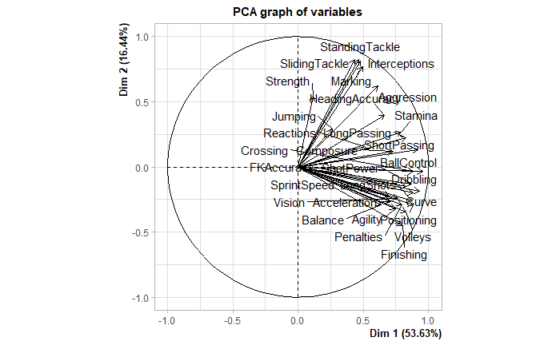

```r
fifapca <- PCA(datapca, scale.unit = TRUE, ncp = 5, graph = TRUE)
```

The function PCA() returns calculations not inherent to prcomp()

```r
print(fifapca)
```

```
**Results for the Principal Component Analysis (PCA)**
The analysis was performed on 18147 individuals, described by 29 variables
*The results are available in the following objects:

   name               description
1  "$eig"             "eigenvalues"
2  "$var"             "results for the variables"
3  "$var$coord"       "coord. for the variables"
4  "$var$cor"         "correlations variables - dimensions"
5  "$var$cos2"        "cos2 for the variables"
6  "$var$contrib"     "contributions of the variables"
7  "$ind"             "results for the individuals"
8  "$ind$coord"       "coord. for the individuals"
9  "$ind$cos2"        "cos2 for the individuals"
10 "$ind$contrib"     "contributions of the individuals"
11 "$call"            "summary statistics"
12 "$call$centre"     "mean of the variables"
13 "$call$ecart.type" "standard error of the variables"
14 "$call$row.w"      "weights for the individuals"
15 "$call$col.w"      "weights for the variables"
```

```r
fifapca$eig
```

```
         eigenvalue percentage of variance cumulative percentage of variance
comp 1  15.55400008            53.63448305                          53.63448
comp 2   4.76822899            16.44216894                          70.07665
comp 3   1.95537523             6.74267320                          76.81933
comp 4   1.36372719             4.70250755                          81.52183
comp 5   1.00741225             3.47383535                          84.99567
comp 6   0.61989335             2.13756327                          87.13323
comp 7   0.39189664             1.35136771                          88.48460
comp 8   0.35250777             1.21554405                          89.70014
comp 9   0.30028307             1.03545887                          90.73560
comp 10  0.27510078             0.94862336                          91.68423
comp 11  0.24227644             0.83543599                          92.51966
comp 12  0.22471140             0.77486691                          93.29453
comp 13  0.22189681             0.76516140                          94.05969
comp 14  0.20196372             0.69642661                          94.75612
comp 15  0.20020534             0.69036323                          95.44648
comp 16  0.17397361             0.59990899                          96.04639
comp 17  0.14795795             0.51019981                          96.55659
comp 18  0.13618015             0.46958673                          97.02618
comp 19  0.12590922             0.43416973                          97.46034
comp 20  0.12139444             0.41860151                          97.87895
comp 21  0.10926715             0.37678326                          98.25573
comp 22  0.09514705             0.32809326                          98.58382
comp 23  0.08335415             0.28742811                          98.87125
comp 24  0.07218853             0.24892596                          99.12018
comp 25  0.06825750             0.23537067                          99.35555
comp 26  0.06512424             0.22456633                          99.58011
comp 27  0.06139202             0.21169661                          99.79181
comp 28  0.03737496             0.12887916                          99.92069
comp 29  0.02300000             0.07931035                         100.00000
```

The eigenvalues show the magnitude of the eigenvectors. The variance percentages of each comp are listed top 3 being: 15.554, 4.76, 1.955 with percentage of variance being 53.63, 16.44, 6.74

so with all those features the dataset has we are able to narrow down with high variance to 3 components

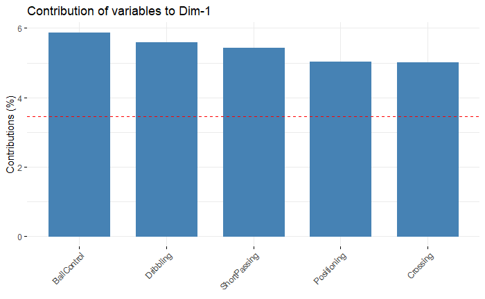

```r
fviz_contrib(fifapca, choice = "var", sort.val = c("desc"), axes = 1, top = 5)
```

Making a graph to show the contribution % of the top 5 variables shows that Ball Control has a strong contribution percentage for the first Component

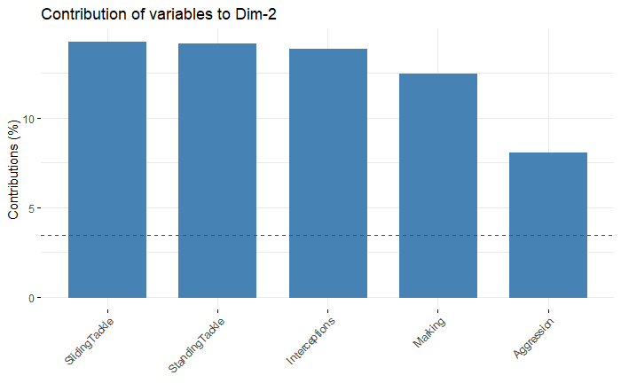

```r
fviz_contrib(fifapca, choice = "var", sort.val = c("desc"), axes = 2, top = 5)
```

The second component shows Sliding Tackles and Standing Tackles as very high contributing variables.

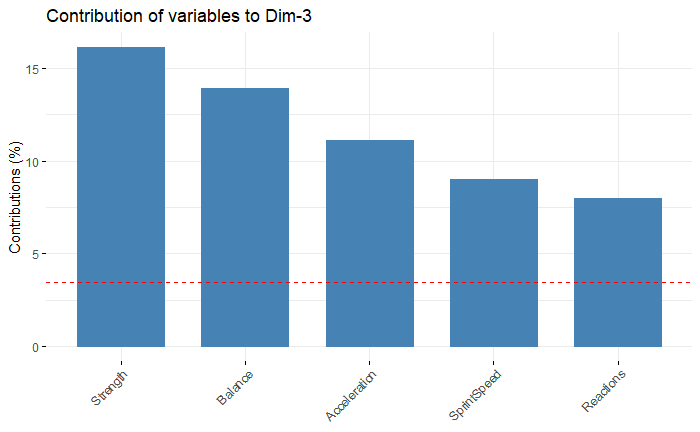

```r
fviz_contrib(fifapca, choice = "var", sort.val = c("desc"), axes = 3, top = 5)
```

and for the third component Strength is a strong contributor.